# act_report

## Report: act_report

#### by Augustine Phiri

- I will create a **250-word-minimum written report** called "act_report.pdf" or "act_report.html" that communicates the insights and displays the visualization(s) produced from my wrangled data.

### Insights

> It is very clear that dogs which receive high favorite counts have more retweets count than those dog names that have less favorite counts. From the scatter plot of favorite count against retweet count we observe some what linear relationship (positive correlation) on average. The higher the favorite count WeRateDogs gave the dog, the more it tended to get retweeted, meaning that people are influenced by the favorite counts.

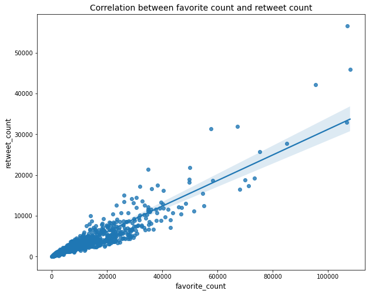

> looking at 12 most used dog names in the dataframe, it was found that the top most famous used dog name is `Charlie` with the value count of `11`, seconded by `Penny`, `Oliver`, `Tucker`, `Cooper` and `Lucy (the only female name)` with value caount of 10.

> Below is the picture of dog names used:

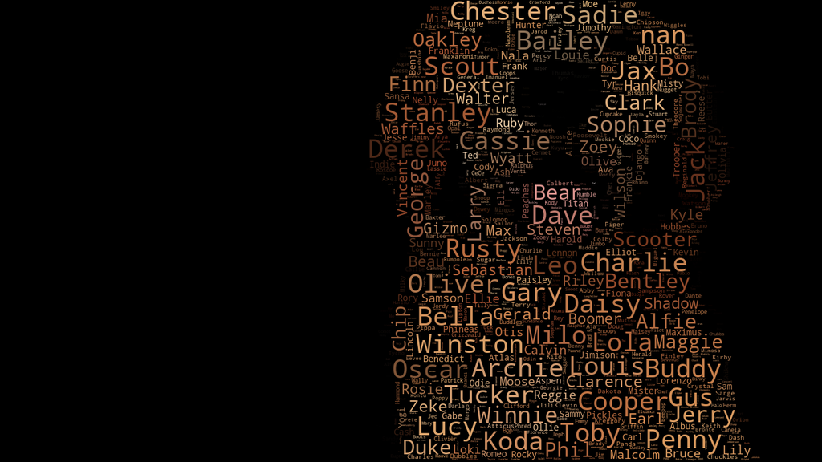

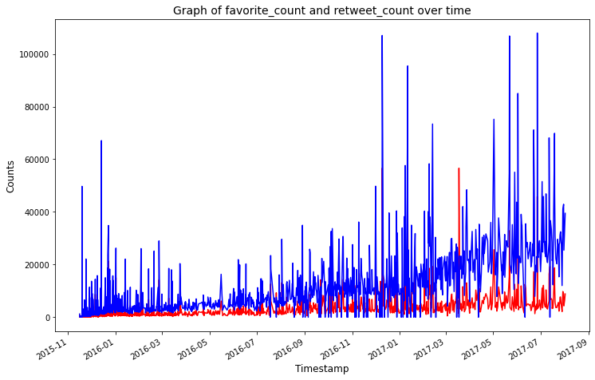

> After ploting the graph of `favorite count` and `retweet count` over time, it was found that the both favorite counts and retweet count increases with time. Se the grath below.